# Reproducible Research: Peer Assessment 1

First of all, the necessary packages are loaded.

```r
library(ggplot2)
library(gridExtra)
library(magrittr)
library(dplyr)
library(knitr)
library(kableExtra)
```

## Loading and preprocessing the data

The activity data is loaded with *read.csv*, with the default parameters. The class of the *date* variable is changed to Date.

```r
A <- read.csv("activity.csv")
A$date <- as.Date(A$date, "%Y-%m-%d")
```

There are **17568** observations of **3** variables in the dataset.

The first 10 lines of the dataset:

|  | steps | date | interval |
| --- | --- | --- | --- |
| 1 | NA | 2012-10-01 | 0 |
| 2 | NA | 2012-10-01 | 5 |
| 3 | NA | 2012-10-01 | 10 |
| 4 | NA | 2012-10-01 | 15 |
| 5 | NA | 2012-10-01 | 20 |
| 6 | NA | 2012-10-01 | 25 |
| 7 | NA | 2012-10-01 | 30 |
| 8 | NA | 2012-10-01 | 35 |
| 9 | NA | 2012-10-01 | 40 |
| 10 | NA | 2012-10-01 | 45 |

A 10-line random sample from the dataset:

|  | steps | date | interval |
| --- | --- | --- | --- |
| 579 | 0 | 2012-10-03 | 10 |
| 1058 | 66 | 2012-10-04 | 1605 |
| 1308 | 0 | 2012-10-05 | 1255 |
| 3792 | 0 | 2012-10-14 | 355 |
| 8516 | 100 | 2012-10-30 | 1335 |
| 9697 | 0 | 2012-11-03 | 1600 |
| 10477 | 433 | 2012-11-06 | 900 |
| 12347 | 0 | 2012-11-12 | 2050 |
| 12938 | NA | 2012-11-14 | 2205 |
| 17042 | 0 | 2012-11-29 | 405 |

## What is mean total number of steps taken per day?

The *mean* and *median* of the daily steps are calculated by first summing up the steps per day, then taking the mean and median of these. NA values are ignored.

```r
dailysteps <- tapply(A$steps, A$date, sum, na.rm = TRUE)
dailysteps.mean <- mean(dailysteps)
dailysteps.median <- median(dailysteps)
```

The mean of the daily steps is **9354.2295082**, while the median is **10395**.

The histogram of the daily steps is drawn below. The plot is also saved in a variable for a later histogram comparison.

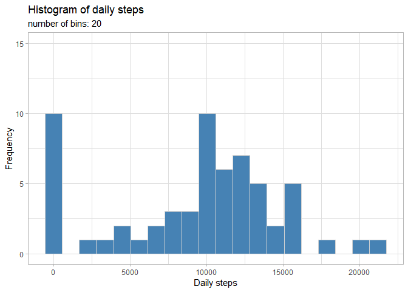

```r
dailyplots <- list()

nbins <- 20
dailyplots$original <-
  qplot(dailysteps, bins = nbins, fill = I("steelblue"), color = I("lightgrey")) +
  theme_light() +
  ylim(0, 15) +
  labs(title = "Histogram of daily steps",
       subtitle = paste("number of bins:", nbins),
       x = "Daily steps",
       y = "Frequency")
```

## What is the average daily activity pattern?

To identify the daily activity pattern, first the average of steps per interval is calculated (NA values are ignored), and then a time series plot is drawn from the result. The interval with the highest activity is also calculated here.

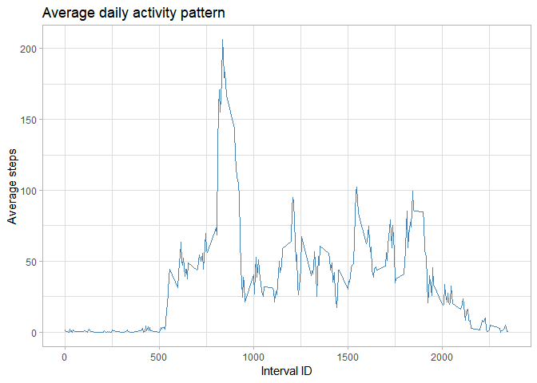

```r
intervals <- unique(A$interval)
steps.mean <- tapply(A$steps, A$interval, mean, na.rm = TRUE)

interval.max <- intervals[steps.mean == max(steps.mean)]

qplot(intervals, steps.mean, geom = "line", color = I("steelblue")) +
  theme_light() +
  labs(title = "Average daily activity pattern", x = "Interval ID", y = "Average steps")
```

The maximum activity is at *interval ID* **835**.

Note that *interval ID* can be mapped to *hours and minutes* of the day in the following way:

- assume the *interval ID* is 4-digit fixed length string
- replace each *space* character with *0*
- the first two digits are the hours, the second two are the minutes of the day.

So for example 5 maps to 00:05, 740 maps to 07:40, 2310 maps to 23:10.

## Imputing missing values

The following lines calculate an overview of the NA values in the dataset: the total number of rows with at least one NA value, and the total number of NAs in each column.

```r
na.totalrows <- sum(sapply(t(A), is.na))
na.percolumns <- lapply(A, function (X) sum(is.na(X)))
```

There are **2304 rows** with NA values in the dataset. The NA values are distributed among the variables as follows:

- **steps:** 2304
- **date:** 0
- **interval:** 0

Each NA value is imputed with the corresponding interval mean of the steps variable. The `intervals` and `steps.mean` objects are re-used from the average daily activity pattern calculation above.

```r
A.imputed <- A
for (i in intervals)
{
  na.indices <- A.imputed$interval == i & is.na(A.imputed$steps)
  A.imputed$steps[na.indices] <- steps.mean[as.character(i)]
}
```

The first 10 lines of the *imputed* dataset:

|  | steps | date | interval |
| --- | --- | --- | --- |
| 1 | 1.7169811 | 2012-10-01 | 0 |
| 2 | 0.3396226 | 2012-10-01 | 5 |
| 3 | 0.1320755 | 2012-10-01 | 10 |
| 4 | 0.1509434 | 2012-10-01 | 15 |
| 5 | 0.0754717 | 2012-10-01 | 20 |
| 6 | 2.0943396 | 2012-10-01 | 25 |
| 7 | 0.5283019 | 2012-10-01 | 30 |
| 8 | 0.8679245 | 2012-10-01 | 35 |
| 9 | 0.0000000 | 2012-10-01 | 40 |
| 10 | 1.4716981 | 2012-10-01 | 45 |

A 10-line sample from the *imputed* dataset (same lines as in the sample from the original dataset):

|  | steps | date | interval |
| --- | --- | --- | --- |
| 579 | 0.000000 | 2012-10-03 | 10 |
| 1058 | 66.000000 | 2012-10-04 | 1605 |
| 1308 | 0.000000 | 2012-10-05 | 1255 |
| 3792 | 0.000000 | 2012-10-14 | 355 |
| 8516 | 100.000000 | 2012-10-30 | 1335 |
| 9697 | 0.000000 | 2012-11-03 | 1600 |
| 10477 | 433.000000 | 2012-11-06 | 900 |
| 12347 | 0.000000 | 2012-11-12 | 2050 |
| 12938 | 3.679245 | 2012-11-14 | 2205 |
| 17042 | 0.000000 | 2012-11-29 | 405 |

The *mean* and *median* of the daily steps in the imputed dataset are calculated in the same way as in the non-imputed dataset: they are calculated by first summing up the steps per day, then taking the mean and median of these. NA values are ignored.

```r
dailystepsimp <- tapply(A.imputed$steps, A.imputed$date, sum, na.rm = TRUE)
dailystepsimp.mean <- mean(dailystepsimp)
dailystepsimp.median <- median(dailystepsimp)
```

A histogram similar to the original dataset’s is created for the imputed dataset, and it is placed into a 2 by 1 plot grid under the original histogram.

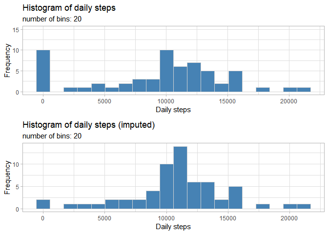

```r
nbins <- 20
dailyplots$imputed  <-
  qplot(dailystepsimp, bins = nbins, fill = I("steelblue"), color = I("lightgrey")) +
  theme_light() +
  labs(title = "Histogram of daily steps (imputed)",
       subtitle = paste("number of bins:", nbins),
       x = "Daily steps",
       y = "Frequency")

grid.arrange(grobs = dailyplots, nrow = 2)
```

## Are there differences in activity patterns between weekdays and weekends?

First the date/time locale is set to *United States* to ensure day names appear in English.

```r
LC_TIME.original <- Sys.getlocale("LC_TIME")
Sys.setlocale("LC_TIME", "us")
```

Then a new variable is added to the *imputed* activity table, which tells if a measurement corresponds to weekdays or weekends. The new **day** variable is a factor with two levels: **weekend** and **weekday**.

```r
A.imputed$day <- weekdays(A.imputed$date, abbreviate = TRUE)
A.imputed$day <- replace(A.imputed$day, A.imputed$day %in% c("Sat", "Sun"), "weekend")
A.imputed$day <- replace(A.imputed$day, A.imputed$day != "weekend", "weekday")
A.imputed$day <- factor(A.imputed$day)

interval.steps.mean <- A.imputed %>% group_by(day, interval) %>% summarize(mean = mean(steps))
```

A 10-line sample from the imputed dataset with *weekday indication*:

|  | steps | date | interval | day |
| --- | --- | --- | --- | --- |
| 579 | 0.000000 | 2012-10-03 | 10 | weekday |
| 1058 | 66.000000 | 2012-10-04 | 1605 | weekday |
| 1308 | 0.000000 | 2012-10-05 | 1255 | weekday |
| 3792 | 0.000000 | 2012-10-14 | 355 | weekend |
| 8516 | 100.000000 | 2012-10-30 | 1335 | weekday |
| 9697 | 0.000000 | 2012-11-03 | 1600 | weekend |
| 10477 | 433.000000 | 2012-11-06 | 900 | weekday |
| 12347 | 0.000000 | 2012-11-12 | 2050 | weekday |
| 12938 | 3.679245 | 2012-11-14 | 2205 | weekday |
| 17042 | 0.000000 | 2012-11-29 | 405 | weekday |

Using this enhanced activity data, a two-panel plot is created, which shows activity means per interval (across days) for *weekdays* and *weekend*.

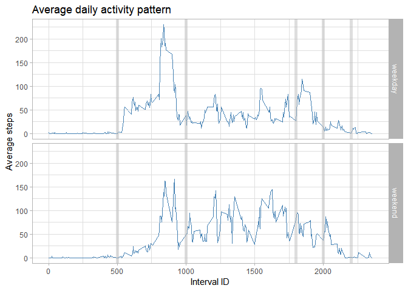

```r
ggplot(interval.steps.mean, aes(interval, mean)) +
  facet_grid(rows = vars(day)) +
  theme_light() +
  geom_line(color = I("steelblue")) +
  geom_vline(xintercept = c(500, 1000, 1800, 2000, 2200), color = I("grey"), size = 2, alpha = 0.5) +
  labs(title = "Average daily activity pattern", x = "Interval ID", y = "Average steps")
```

This comparison indicates the following:

- higher morning activity on weekdays (approx. between activity IDs 500 and 1000, which correspond to 5:00 and 10:00 in the morning)
- higher daytime activity on weekends (approx. between activity IDs 1000 and 1800, which correspond to 10:00 and 18:00 hours)
- slightly higher late-afternoon activity on weekdays (approx. between 18:00 and 20:00 hours)
- slightly higher early-night activity on weekends (after approx. 20:00 hours)
- there is no significant difference in activity during late-night and early-morning hours (approx. between 22:00 and 5:00 hours)

Note that these are only assumptions, which must be verified. Supporting lines are drawn at activity IDs corresponding to the named hours.

Finally, the data/time locale is reset to the original setting.

```r
Sys.setlocale("LC_TIME", LC_TIME.original)
```